# SOA e Predição com Ajuda de Experts

MAC5005 - Fundamentos Matemáticos do Aprendizado Sequencial e Online

Victor S. Portella

IME-USP

2026-03-02

## Relembrando - Classificação Binária Online

Para cada rodada $t = 1, \dotsc, T$:

- O **Adversário** escolhe um $x_t \in \cX$
- O **Jogador/Algoritmo** escolhe uma predição $p_t \in \cY = \{0,1\}$
- O **Adversário** escolhe e revela o rótulo real $y_t \in \{0,1\}$

Assim como no aprendizado estatístico, vamos começar pelo **caso realizável**:

Temos uma classe de hipóteses $\cH \subseteq \cY^\cX$ conhecida, e existe $h^* \in \cH$ tal que
$$y_t = h^*(x_t) \quad \text{para todo}~t \in [T] := \{1, \dotsc, T\}.$$

**Importante: não assumimos mais nada sobre o adversário**

**Pergunta** Qual o número máximo de erros que o algoritmo pode fazer?

## Relembrando - Algoritmos para $\cH$ finito

$$\cV_t := \{ h \in \cH \;\colon\; h(x_s) = y_s~\text{para todo}~s < t \}$$

Na rodada $t \in [T]$ , O algoritmo **CONSISTENTE**

- Escolhe $h_t \in \cV_t$
- Define $p_t = h_t(x_t)$

Na rodada $t \in [T]$ , O algoritmo **HALVING**

- Escolhe $p_t \in \{0,1\}$ que maximiza o tamanho do conjunto
  $$\{ h \in \cV_t \colon h(x_t) = p_t\}$$

Para $p_t$ dado por **CONSISTENTE** e **HALVING** (resp.), temos
$$\sum_{t = 1}^T \ones[p_t \neq y_t] \leq |\cH| - 1 \quad \text{e} \quad \sum_{t = 1}^T \ones[p_t \neq y_t] \leq \log_2(|\cH|)$$

## Relembrando - Árvores de estratégia

Uma **árvore de estratégia** (do adversário) é uma árvore binária completa de altura $T$ com conjunto de vértices é $v_1, \dotsc, v_{2^{T+1} -1} \in \cX$ com $v_1$ de raiz.

**Arestas e Notação**:

- $\DESC(v_i,0) := v_{2i}$ (filho esquerdo de $v$)
- $\DESC(v,1) := v_{2i + 1}$ (filho direito de $v$)

As escolhas do **adversário** são dadas pela árvore. Começando pela raiz $v = v_1$

- **Adversário** escolhe $x_t = v$;
- **Adversário** espera $p_t$, e define $y_t = |1 - p_t|$;
- **Adversário** atualia $v = \DESC(v, y_t)$.

## Relembrando - Dimensão de Littlestone

Uma árvore de estratégia com vértices $(v_1, \dotsc, v_{2^{T + 1}-1})$ é **fragmentada** por $\cH$ se **para todo** $y \in \{0,1\}^T$ , definindo $x_1 = v_1$ e
$$x_{t+1} = \DESC(x_{i}, y_i) \quad \text{para todo}~t \in [T-1],$$
existe $h \in \cH$ tal que $h(x_t) = y_t$ para todo $t \in [T]$.

Assim como em aprendizado estatístico, a ideia de **fragmentação** nos leva a uma noção de **dimensão de $\cH$**

A **dimensão de Littlestone** $\LDim(\cH)$ de $\cH$ o maior $T \in \bN$ tal que existe uma árvore de estratégia de profundiade $T$ fragmentada por $\cH$

Nenhum algoritmo pro jogador contra um adversário realizado por $\cH$ pode garantir menos que $\LDim(\cH)$ erros.

# Um Algoritmo Ótimo para Classificação Binária Online

## Standard Optimal Algorithm (SOA)

Na rodada $t \in [T]$ , o algoritmo **SOA**

- Escolhe $p_t \in \{0,1\}$ que maximiza o tamanho do conjunto maximiza a dimensão de Littlestone de
  $$\{ h \in \cV_t \colon h(x_t) = p_t\}$$

Para $p_t$ dado por **SOA**,
$$\sum_{t = 1}^T \ones[p_t \neq y_t] \leq \LDim(\cH)$$

No caso realizável, existe um algoritmo que sofre no máximo um número finito de erros em classificação binária online **se e só se** $\LDim(\cH) < \infty$

## Comparando $\LDim(\cH)$ com $\VC(\cH)$

Para qualquer $\cH \subseteq \cX^{\{0,1\}}$, temos que
$$\VC(\cH) \leq \LDim(\cH).$$

## Extra - Aprendizado Online e Privado

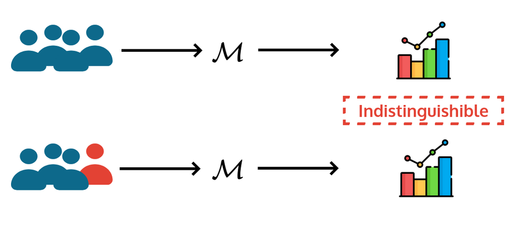

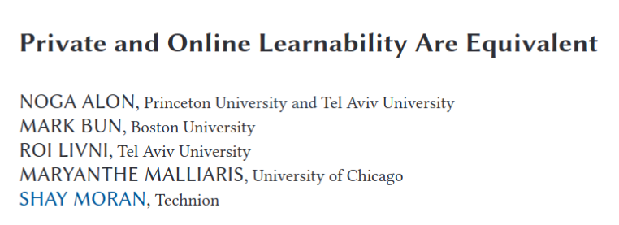

# Classificação Binária Online Agnóstica e Predição com Ajuda de Experts

## Predição com Ajuda de Experts

Vamos estudar primeiro **Predição com Ajuda de Experts**

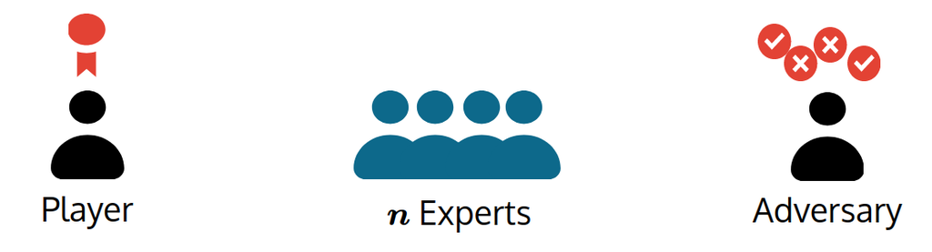

Para cada rodada $t = 1, \dotsc, T$:

- O **Jogador/Algoritmo** escolhe um expert $i_t \in [d]$ para seguir
- O **Adversário** escolhe custos $\ell_t \in [0,1]^d$ para os experts
- O **Jogador/Algoritmo** sofre o custo $\ell_t(i)$

## Exemplo

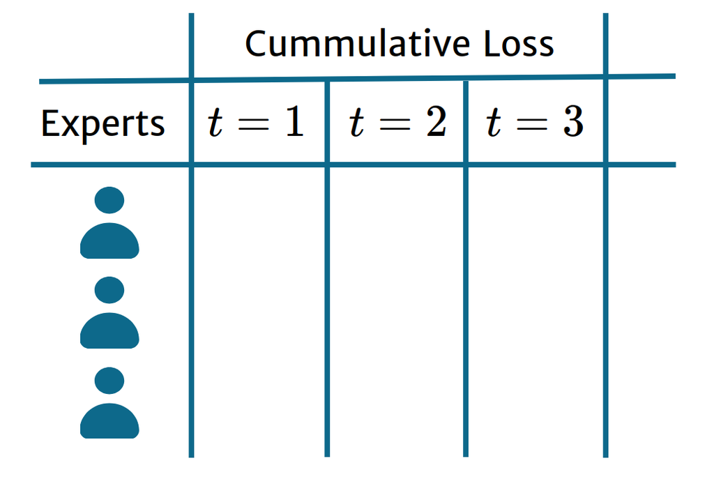

## Medida de Desempenho: Regret

No pior caso, o jogador **erra toda rodada**.

Ou seja, numero de erros **não é informativo** nesse caso.

**Alternativa - Regret:** comparar custo com o do melhor expert do jogo.
$$\Regret(T) = \sum_{t=1}^T \ell_t(i_t) - \min_{i \in [d]} \sum_{t = 1}^T \ell_t(i)$$

**Objetivo:** garantir regret sublinear no número de rodadas $T$ :
$$\frac{\Regret(T)}{T} \longrightarrow 0 \quad \text{quando} \quad T \to \infty.$$

**Má noticia:** ainda muito dificil!

Impossibilidade de Cover Para qualquer algoritmo, existem custos tais que
$$\Regret(T) \geq T/2.$$

## Solução: Aleatorização/Convexificação

**Solução**: aleatorizar a escolha do jogador

Equivalente a **“convexificar”** a escolha do jogador

- O **Jogador/Algoritmo** escolhe uma distribuição $p_t \in \Delta_d$ sobre os experts, onde
  $$\Delta_d = \Big \{ p \in [0,1]^d \; \colon\; \sum_{i=1}^d p_i = 1 \Big \}$$
- O **Adversário** escolhe custos $\ell_t \in [0,1]^d$ para os experts
- O **Jogador/Algoritmo** sofre o custo esperado $\ell_t^\T p_t$

## Método dos Pesos Multiplicativos/Hedge

**MWU($T, \eta$)**:

Defina $w_1 := \ones$

Para $t = 1, \dotsc, T$:

- **Jogador** revela
  $$p_t = \frac{w_t}{\lVert w_t\rVert_1} \in \Delta_d$$
- **Adversário** revela os custos $\ell_t \in [0,1]^d$ e **Jogador** sofre custo $\ell_t^\T p_t$
- **Jogador** atualiza os pesos $p_{t+1}$ para a próxima rodada:
  $$w_{t+1}(i) := w_t(i) \cdot \exp(-\eta \ell_t(i)) \quad \text{para todo}~i \in [d]$$

Para $\eta > 0$, o algoritmo MWU($T, \eta$) com $\eta = \sqrt{2 \log d / T}$ garante
$$\Regret(T) \leq \sqrt{2 T \ln d}.$$

## Aplicação: Classificação com $\cH$ finito

Podemos usar MWU para **classicação binária online** com $\cH$ finito

Caso “**aleatorizado/convexificado**”, onde a cada rodada $t$:

- O **Jogador** escolhe faz uma predição $\hat{y}_t \in [0,1]$
- O **Adversário** revela $y_t \in \{0,1\}$ e o jogador sofre custo $|\hat{y}_t - y_t|$

O **regret** para classificação binária online com respeito a classe hipóteses $\cH$ é
$$\Regret(\cH, T) = \sum_{t=1}^T |\hat{y}_t - y_t| - \inf_{h \in \cH} \sum_{t=1}^T |h(x_t) - y_t|$$

Se $\cH$ é finito, usando MWU o jogador pode garantir
$$\Regret(\cH, T) \leq \sqrt{2T\ln(|\cH|)}.$$